# Descriptive Analysis

Hannah Schweren

2024-03-28

This script provides code to analyse the descriptive indicators and output the results in boxplots and tables. The data contains some outliers due to a couple of famous politicians. DUe to these outliers, the mean values risk being distorted. Therefore, a logarithm transformation with base two is performed to make the mean a more robust indicator for comparison. I chose the log2 scale to improve visibility while also allowing for an intuitive interpretation of the results (an increase by one unit on the transformed scale corresponds to a doubling of the original value).

### necessary packages

```r
library(legislatoR)
library(WikipediR)
library(rvest)
library(dplyr)
library(stringr)
library(ggplot2)
library(tm)
library(MatchIt)
library(quanteda)
library(purrr)
library(tidyverse)
library(rstatix)
library(ggpubr)
library(effsize)
library(kableExtra)
library(magick)
library(webshot2)
library(here)
library(scales)
library(corrplot)
library(tibble)
```

### Get the clean data

```r
deu <- read.csv(here("data", "clean", "deu.csv"))
matched_data <- read.csv(here("data", "clean", "matched_data.csv"))
```

### Necessary functions

```r
#function adding stars according to significance of t-test in the boxplot figures
add_stars <- function(p_value) {
  if (p_value < 0.001) {
    return("***")
  } else if (p_value < 0.01) {
    return("**")
  } else if (p_value < 0.05) {
    return("*")
  } else {
    return("")
  }
}

########################################################################################################

#function to calculate the descriptive parameters

calculate_statistics_log <- function(df) {
  # Initialize an empty dataframe for the results
  results <- tibble()

  # Iterate over each variable of interest
  for (variable in c("text_length_log2", "text_length_career_log2", "text_length_live_log2", "number_of_links_log2", "total_edits_log2")) {
    # Extract data for male and female group
    data_male <- df %>%
      filter(sex == "male") %>%
      pull(variable)
    data_female <- df %>%
      filter(sex == "female") %>%
      pull(variable)

    # Check if data exists for both groups
    if (length(data_male) == 0 | length(data_female) == 0) {
      next # Skip to next iteration if data is missing for either group
    }

    # Perform Welch's t-test
    test <- t.test(data_male, data_female, na.action = na.exclude)

    # Calculate Cohen's d effect size
    d <- cohen.d(data_male, data_female, na.rm = TRUE)$estimate

    # Calculate means on log-transformed data
    mean_male_log <- mean(data_male, na.rm = TRUE)
    mean_female_log <- mean(data_female, na.rm = TRUE)

    # Back-transform means to original scale to make the scaling consistent to the boxplots
    mean_male_original <- 2^mean_male_log
    mean_female_original <- 2^mean_female_log

    # Assign new names to the variables
    if (variable == "text_length_log2") {
      variable_name <- "Text length"
    } else if (variable == "text_length_career_log2") {
      variable_name <- "Text length, career section"
    } else if (variable == "text_length_live_log2") {
      variable_name <- "Text length, life section"
    } else if (variable == "number_of_links_log2") {
      variable_name <- "Number of links"
    } else if (variable == "total_edits_log2") {
      variable_name <- "Number of edits"
    }

    # Append results to the dataframe
    results <- rbind(results, tibble(
      Variable = variable_name,
      "Female Mean" = mean_female_original,
      "Male Mean" = mean_male_original,
      P_Value = test$p.value,
      "Effect size" = d
    ))
  }

  return(results)
}


########################################################################################################

# Function to generate and save a formatted table containing the descriptive indicators
generate_table <- function(data, file_name) {
  # Function to format p-values with stars
  combine_p_value_and_stars <- function(p_value) {
    stars <- ifelse(p_value < .001, "***",
                    ifelse(p_value < .01, "**",
                           ifelse(p_value < .05, "*",
                                  ifelse(p_value < .1, ".", "ns"))))

    formatted_p_value <- format(round(p_value, 3), nsmall = 3)  # Format p-value with 3 digits

    if(grepl("\\*", stars)) {
      return(sprintf("<b>%s%s</b>", formatted_p_value, stars))
    } else {
      return(formatted_p_value)
    }
  }

  # Format P-Values using the custom function
  data$P_Value <- sapply(data$P_Value, combine_p_value_and_stars)

  # Prepare the data set for table creation, round digits
  data <- data %>%
    select(everything()) %>%
    mutate(across(where(is.numeric), round, digits = 3))

  # Create the table
  descriptive_table <- kable(data, "html", escape = FALSE) %>%
    kable_styling("striped", full_width = F) %>%
    collapse_rows(columns = 1, valign = "top")

  # Save the table as a PNG image
  save_kable(descriptive_table, file = here("visualisations", paste0(file_name, ".png")))

  return(descriptive_table)
}
```

### create boxplots

The following code creates boxplots for each descriptive feature, starting with the unmatched data

1.1. Text length

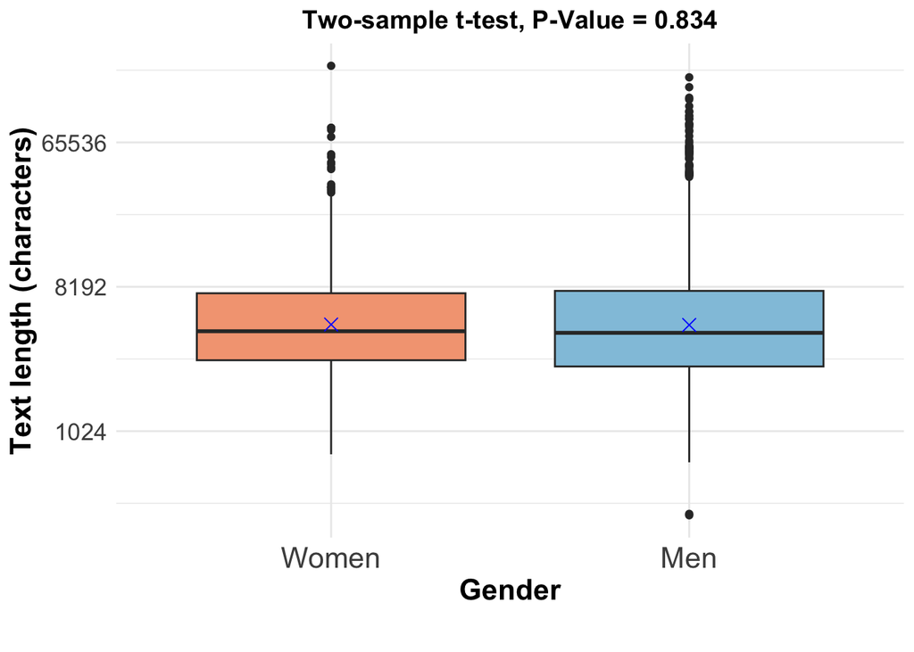

```r
#Put NAs for cases where the section extraction did not work out properly. Where text length is <60, I exclude the observation in this analyis
descriptive_data_deu <- deu
descriptive_data_deu$text_length_live[descriptive_data_deu$text_length_live < 60] <- NA
descriptive_data_deu$text_length_career[descriptive_data_deu$text_length_career < 60] <- NA


#conduct the logarithmic transformation with basis 2 for the t-test
descriptive_data_deu$text_length_log2 <- log2(descriptive_data_deu$text_length)

# calculate the p-value
t_test_result <- t.test(text_length_log2 ~ sex, data = descriptive_data_deu)

#create a boxplot to viualise the descriptive indicators
deu_text_length <- ggplot(descriptive_data_deu, aes(x = factor(sex, levels = c("female", "male"), labels = c("Women", "Men")), y = text_length, fill = factor(sex, levels = c("female", "male")))) +
  geom_boxplot() +
    scale_fill_manual(values = c("female" = "#f4a582", "male" = "#92c5de")) +
  labs(title = paste("Two-sample t-test, P-Value = ", round(t_test_result$p.value, 3), add_stars(t_test_result$p.value), sep = ""), #add p-value on top of the boxplot
       x = "Gender",
       y = "Text length (characters)", caption = "") +
  stat_summary(fun = mean, geom = "point", aes(group = sex),
               shape = 4, size = 3, color = "blue") + # add a blue cross to mark the mean value in the boxplot
  theme_minimal() +
  theme(
    panel.background = element_rect(fill = "white", colour = "white"), # make the background white
    plot.background = element_rect(fill = "white", colour = NA),
    plot.title = element_text(hjust = 0.5, size = 14, face = "bold"), # center and fix size for the title
    plot.caption = element_text(hjust = 0.5, size = 16),
    axis.title.x = element_text(size = 16, , face = "bold"), # fix size for axis titles and text
    axis.title.y = element_text(size = 16, , face = "bold"),
    axis.text.x = element_text(size = 16),
    axis.text.y = element_text(size = 13)
  ) +
  guides(fill = FALSE)+
  scale_y_continuous(trans = 'log2') # logarithmic transformation of the data but add the original scale in order to make it better interpretable
#save the plot
ggsave(here("visualisations", "deu_boxplot1.pdf"), plot = deu_text_length, width = 5, height = 6, units = "in", dpi = 600)

deu_text_length
```

The same procedure follows for all indicators in the unmatched and matched data

1.2. Text length life section

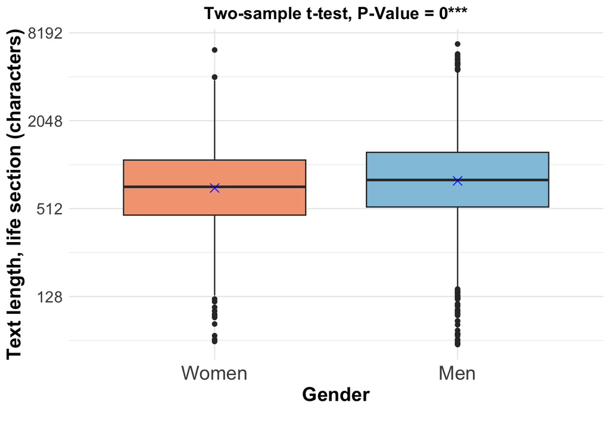

```r
descriptive_data_deu$text_length_life_log2 <- log2(descriptive_data_deu$text_length_live)

t_test_result <- t.test(text_length_life_log2 ~ sex, data = descriptive_data_deu, na.action = na.exclude)




deu_text_length_life <- ggplot(descriptive_data_deu, aes(x = factor(sex, levels = c("female", "male"), labels = c("Women", "Men")), y = text_length_live, fill = factor(sex, levels = c("female", "male")))) +
  geom_boxplot() +
  scale_fill_manual(values = c("female" = "#f4a582", "male" = "#92c5de")) +
  labs(title = paste("Two-sample t-test, P-Value = ", round(t_test_result$p.value, 3), add_stars(t_test_result$p.value), sep = ""),
       x = "Gender",
       y = "Text length, life section (characters)",
       caption = "") +
  stat_summary(fun = mean, geom = "point", aes(group = sex),
               shape = 4, size = 3, color = "blue") +
  theme_minimal() +
  theme(
    panel.background = element_rect(fill = "white", colour = "white"),
    plot.background = element_rect(fill = "white", colour = NA),
    plot.title = element_text(hjust = 0.5, size = 14, face = "bold"),
    plot.caption = element_text(hjust = 0.5, size = 16),
    axis.title.x = element_text(size = 16, face = "bold"),
    axis.title.y = element_text(size = 16, face = "bold"),
    axis.text.x = element_text(size = 16),
    axis.text.y = element_text(size = 13)
  ) +
  guides(fill = FALSE)+
  scale_y_continuous(trans = 'log2')


ggsave(here("visualisations", "deu_boxplot2.pdf"), plot = deu_text_length_life, width = 5, height = 6, units = "in", dpi = 600)

deu_text_length_life
```

1.3. Text length career section

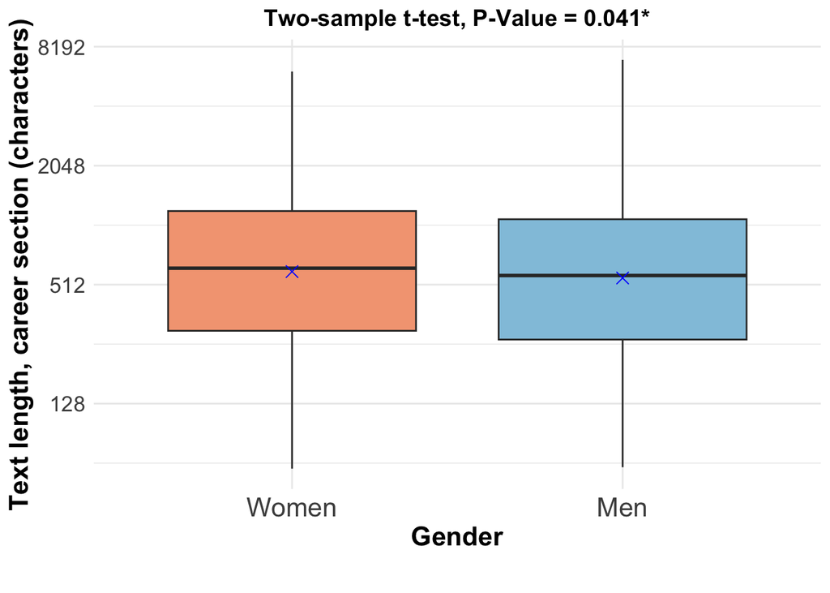

```r
descriptive_data_deu$text_length_career_log2 <- log2(descriptive_data_deu$text_length_career)
t_test_result <- t.test(text_length_career_log2 ~ sex, data = descriptive_data_deu, na.action = na.exclude)



deu_text_length_career <- ggplot(descriptive_data_deu, aes(x = factor(sex, levels = c("female", "male"), labels = c("Women", "Men")), y = text_length_career, fill = factor(sex, levels = c("female", "male")))) +
  geom_boxplot() +
    scale_fill_manual(values = c("female" = "#f4a582", "male" = "#92c5de")) +
  labs(title = paste("Two-sample t-test, P-Value = ", round(t_test_result$p.value, 3), add_stars(t_test_result$p.value), sep = ""),
       x = "Gender",
       y = "Text length, career section (characters)", caption = "") +
  stat_summary(fun = mean, geom = "point", aes(group = sex),
               shape = 4, size = 3, color = "blue") +
  theme_minimal() +
  theme(
    panel.background = element_rect(fill = "white", colour = "white"),
    plot.background = element_rect(fill = "white", colour = NA),
    plot.title = element_text(hjust = 0.5, size = 14, face = "bold"),
    plot.caption = element_text(hjust = 0.5, size = 16),
    axis.title.x = element_text(size = 16, , face = "bold"),
    axis.title.y = element_text(size = 16, , face = "bold"),
    axis.text.x = element_text(size = 16),
    axis.text.y = element_text(size = 13)
  ) +
  guides(fill = FALSE)+
  scale_y_continuous(trans = 'log2')

ggsave(here("visualisations", "deu_boxplot3.pdf"), plot = deu_text_length_career, width = 5, height = 6, units = "in", dpi = 600)

deu_text_length_career
```

1.4. Number of links

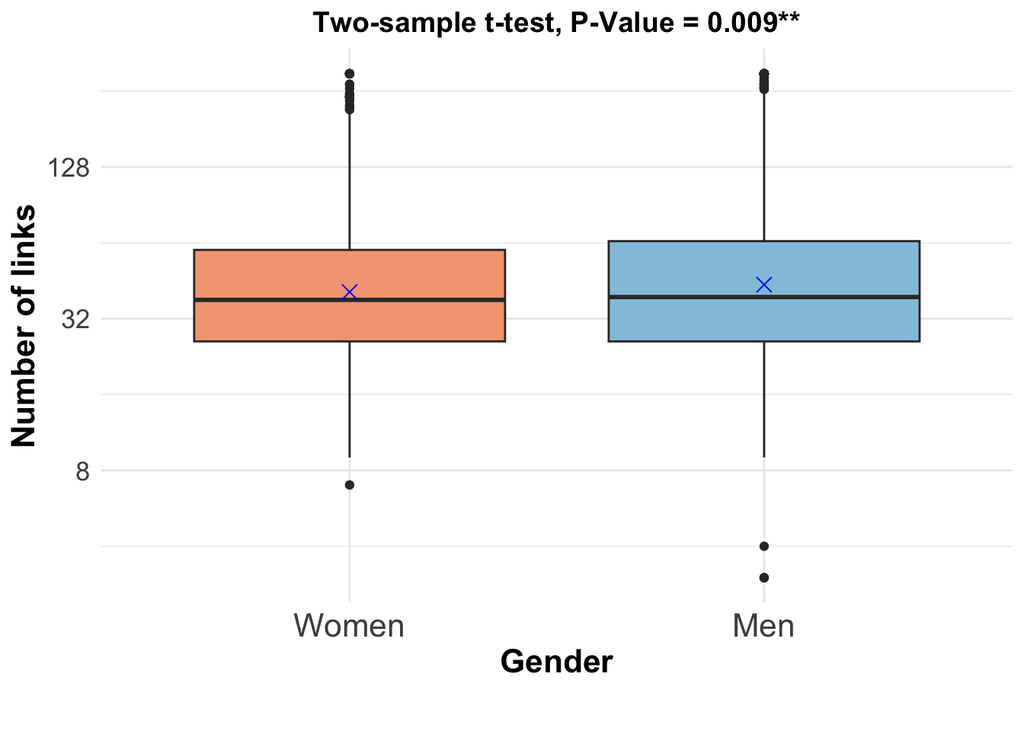

```r
deu$number_of_links_log2 <- log2(deu$number_of_links)
t_test_result <- t.test(number_of_links_log2 ~ sex, data = deu)




deu_links <- ggplot(deu, aes(x = factor(sex, levels = c("female", "male"), labels = c("Women", "Men")), y = number_of_links, fill = factor(sex, levels = c("female", "male")))) +
  geom_boxplot() +
    scale_fill_manual(values = c("female" = "#f4a582", "male" = "#92c5de")) +
  labs(title = paste("Two-sample t-test, P-Value = ", round(t_test_result$p.value, 3), add_stars(t_test_result$p.value), sep = ""),
       x = "Gender",
       y = "Number of links", caption = "") +
  stat_summary(fun = mean, geom = "point", aes(group = sex),
               shape = 4, size = 3, color = "blue") +
  theme_minimal() +
  theme(
    panel.background = element_rect(fill = "white", colour = "white"),
    plot.background = element_rect(fill = "white", colour = NA),
    plot.title = element_text(hjust = 0.5, size = 14, face = "bold"),
    plot.caption = element_text(hjust = 0.5, size = 16),
    axis.title.x = element_text(size = 16, , face = "bold"),
    axis.title.y = element_text(size = 16, , face = "bold"),
    axis.text.x = element_text(size = 16),
    axis.text.y = element_text(size = 13)
  ) +
  guides(fill = FALSE) +
  scale_y_continuous(trans = 'log2')

ggsave(here("visualisations", "deu_boxplot4.pdf"), plot = deu_links, width = 5, height = 6, units = "in", dpi = 600)

deu_links
```

1.5. Number of page edits

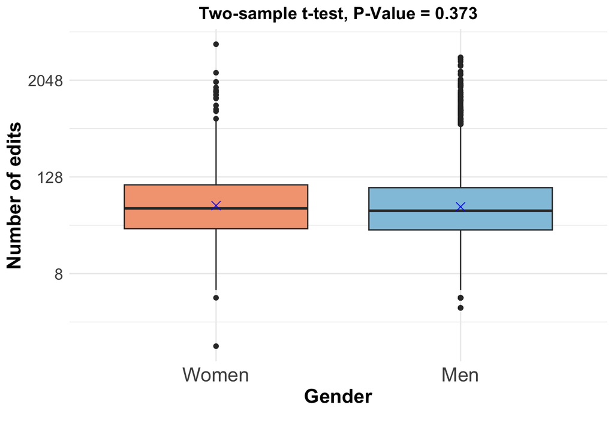

```r
 deu$total_edits_log2 <- log2(deu$total_edits)

t_test_result <- t.test(total_edits_log2 ~ sex, data = deu)



deu_edits <- ggplot(deu, aes(x = factor(sex, levels = c("female", "male"), labels = c("Women", "Men")), y = total_edits, fill = factor(sex, levels = c("female", "male")))) +
  geom_boxplot() +
    scale_fill_manual(values = c("female" = "#f4a582", "male" = "#92c5de")) +
  labs(title = paste("Two-sample t-test, P-Value = ", round(t_test_result$p.value, 3), add_stars(t_test_result$p.value), sep = ""),
       x = "Gender",
       y = "Number of edits", caption = "") +
  stat_summary(fun = mean, geom = "point", aes(group = sex),
               shape = 4, size = 3, color = "blue") +
   theme_minimal() +
  theme(
    panel.background = element_rect(fill = "white", colour = "white"),
    plot.background = element_rect(fill = "white", colour = NA),
    plot.title = element_text(hjust = 0.5, size = 14, face = "bold"),
    plot.caption = element_text(hjust = 0.5, size = 16),
    axis.title.x = element_text(size = 16, , face = "bold"),
    axis.title.y = element_text(size = 16, , face = "bold"),
    axis.text.x = element_text(size = 16),
    axis.text.y = element_text(size = 13)
  ) +
  guides(fill = FALSE)+
  scale_y_continuous(trans = 'log2')

ggsave(here("visualisations", "deu_boxplot5.pdf"), plot = deu_edits, width = 5, height = 6, units = "in", dpi = 600)

deu_edits
```

The following chunks create the plots for the matched data

2.1. Text length

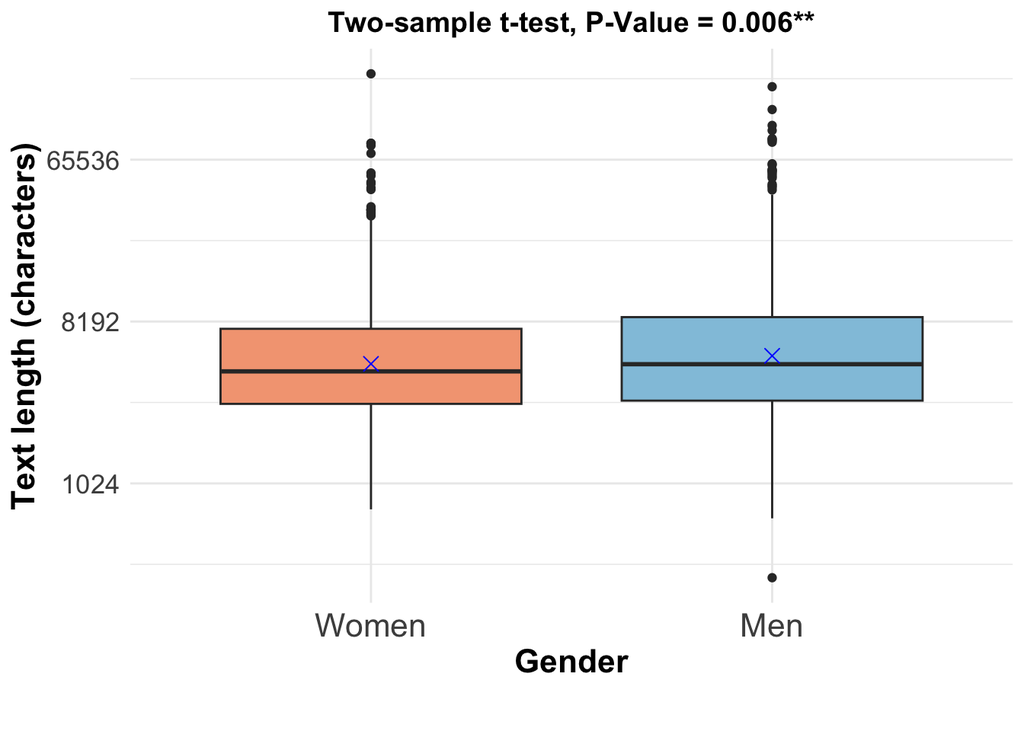

```r
descriptive_data_matched <- matched_data
descriptive_data_matched$text_length_live[descriptive_data_matched$text_length_live < 60] <- NA
descriptive_data_matched$text_length_career[descriptive_data_matched$text_length_career < 60] <- NA


descriptive_data_matched$text_length_log2 <- log2(descriptive_data_matched$text_length)
t_test_result <- t.test(text_length_log2 ~ sex, data = descriptive_data_matched)


matched_data_text_length <- ggplot(matched_data, aes(x = factor(sex, levels = c("female", "male"), labels = c("Women", "Men")), y = text_length, fill = factor(sex, levels = c("female", "male")))) +
  geom_boxplot() +
    scale_fill_manual(values = c("female" = "#f4a582", "male" = "#92c5de")) +
  labs(title = paste("Two-sample t-test, P-Value = ", round(t_test_result$p.value, 3), add_stars(t_test_result$p.value), sep = ""),
       x = "Gender",
       y = "Text length (characters)", caption = "") +
  stat_summary(fun = mean, geom = "point", aes(group = sex),
               shape = 4, size = 3, color = "blue") +
  theme_minimal() +
  theme(
    panel.background = element_rect(fill = "white", colour = "white"),
    plot.background = element_rect(fill = "white", colour = NA),
    plot.title = element_text(hjust = 0.5, size = 14, face = "bold"),
    plot.caption = element_text(hjust = 0.5, size = 16),
    axis.title.x = element_text(size = 16, , face = "bold"),
    axis.title.y = element_text(size = 16, , face = "bold"),
    axis.text.x = element_text(size = 16),
    axis.text.y = element_text(size = 13)
  ) +
  guides(fill = FALSE)+
  scale_y_continuous(trans = 'log2')

ggsave(here("visualisations", "matched_data_boxplot1.pdf"), plot = matched_data_text_length, width = 5, height = 6, units = "in", dpi = 600)

matched_data_text_length
```

2.2. Text length life section

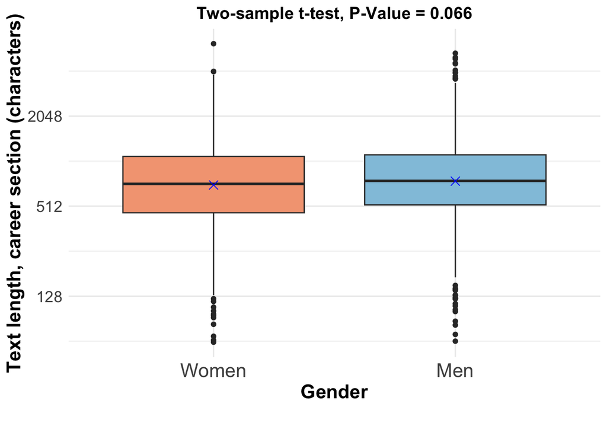

```r
descriptive_data_matched$text_length_life_log2 <- log2(descriptive_data_matched$text_length_live)
t_test_result <- t.test(text_length_life_log2 ~ sex, data = descriptive_data_matched, na.action = na.exclude)



matched_text_length_life <- ggplot(descriptive_data_matched, aes(x = factor(sex, levels = c("female", "male"), labels = c("Women", "Men")), y = text_length_live, fill = factor(sex, levels = c("female", "male")))) +
  geom_boxplot() +
    scale_fill_manual(values = c("female" = "#f4a582", "male" = "#92c5de")) +
  labs(title = paste("Two-sample t-test, P-Value = ", round(t_test_result$p.value, 3), add_stars(t_test_result$p.value), sep = ""),
       x = "Gender",
       y = "Text length, career section (characters)", caption = "") +
  stat_summary(fun = mean, geom = "point", aes(group = sex),
               shape = 4, size = 3, color = "blue") +
  theme_minimal() +
  theme(
    panel.background = element_rect(fill = "white", colour = "white"),
    plot.background = element_rect(fill = "white", colour = NA),
    plot.title = element_text(hjust = 0.5, size = 14, face = "bold"),
    plot.caption = element_text(hjust = 0.5, size = 16),
    axis.title.x = element_text(size = 16, , face = "bold"),
    axis.title.y = element_text(size = 16, , face = "bold"),
    axis.text.x = element_text(size = 16),
    axis.text.y = element_text(size = 13)
  ) +
  guides(fill = FALSE)+
  scale_y_continuous(trans = 'log2')

ggsave(here("visualisations", "matched_data_boxplot2.pdf"), plot = matched_text_length_life, width = 5, height = 6, units = "in", dpi = 600)

matched_text_length_life
```

2.3. Text length career section

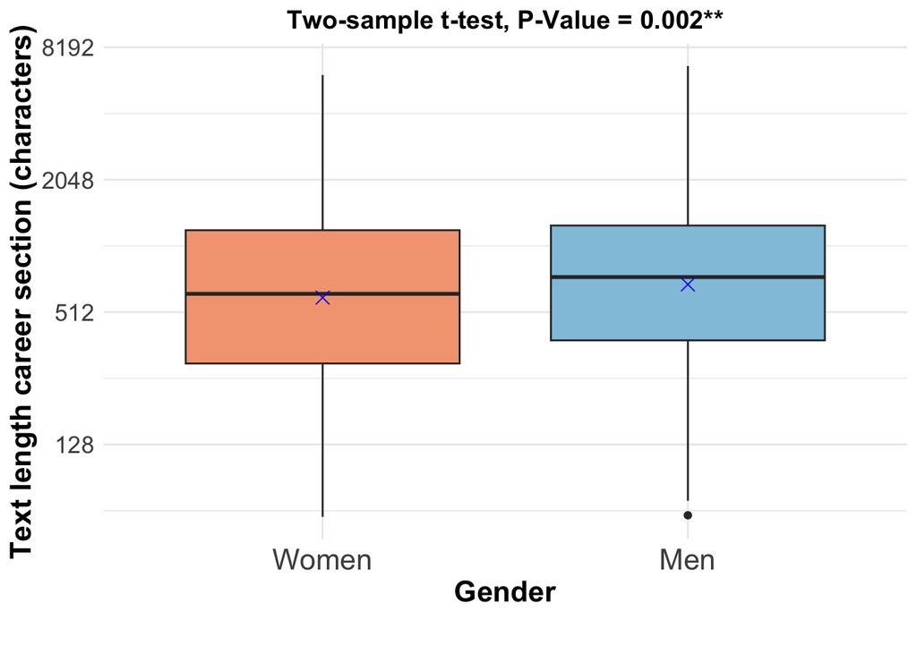

```r
descriptive_data_matched$text_length_career_log2 <- log2(descriptive_data_matched$text_length_career)
t_test_result <- t.test(text_length_career_log2 ~ sex, data = descriptive_data_matched, na.action = na.exclude)


matched_text_length_career <- ggplot(descriptive_data_matched, aes(x = factor(sex, levels = c("female", "male"), labels = c("Women", "Men")), y = text_length_career, fill = factor(sex, levels = c("female", "male")))) +
  geom_boxplot() +
    scale_fill_manual(values = c("female" = "#f4a582", "male" = "#92c5de")) +
  labs(title = paste("Two-sample t-test, P-Value = ", round(t_test_result$p.value, 3), add_stars(t_test_result$p.value), sep = ""),
       x = "Gender",
       y = "Text length career section (characters)", caption = "") +
  stat_summary(fun = mean, geom = "point", aes(group = sex),
               shape = 4, size = 3, color = "blue") +
  theme_minimal() +
  theme(
    panel.background = element_rect(fill = "white", colour = "white"),
    plot.background = element_rect(fill = "white", colour = NA),
    plot.title = element_text(hjust = 0.5, size = 14, face = "bold"),
    plot.caption = element_text(hjust = 0.5, size = 16),
    axis.title.x = element_text(size = 16, , face = "bold"),
    axis.title.y = element_text(size = 16, , face = "bold"),
    axis.text.x = element_text(size = 16),
    axis.text.y = element_text(size = 13)
  ) +
  guides(fill = FALSE)+
  scale_y_continuous(trans = 'log2')


ggsave(here("visualisations", "matched_data_boxplot3.pdf"), plot = matched_text_length_career, width = 5, height = 6, units = "in", dpi = 600)

matched_text_length_career
```

2.4. Number of links

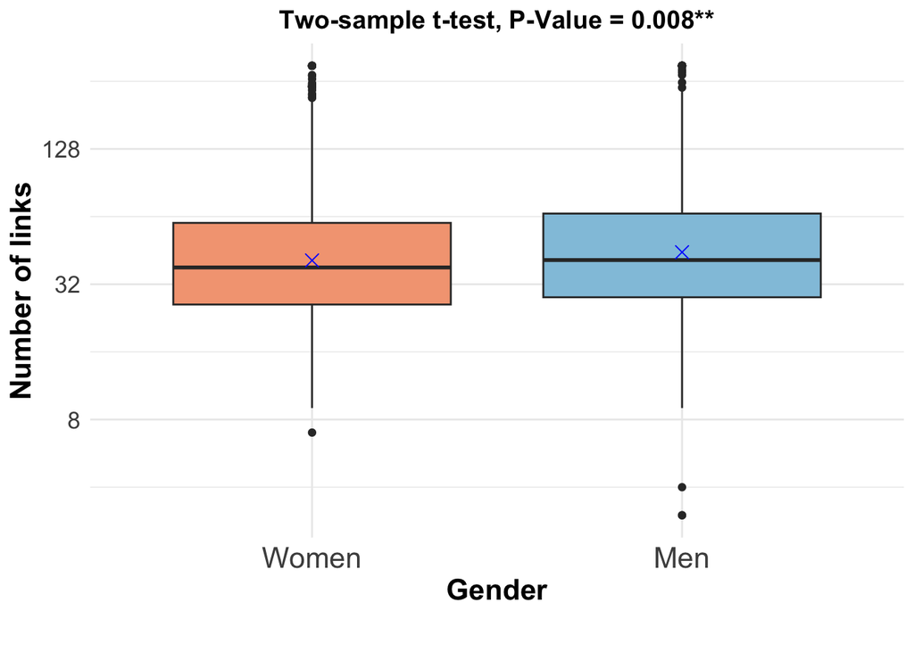

```r
matched_data$number_of_links_log2 <- log2(matched_data$number_of_links)

t_test_result <- t.test(number_of_links_log2 ~ sex, data = matched_data)

matched_data_links <- ggplot(matched_data, aes(x = factor(sex, levels = c("female", "male"), labels = c("Women", "Men")), y = number_of_links, fill = factor(sex, levels = c("female", "male")))) +
  geom_boxplot() +
    scale_fill_manual(values = c("female" = "#f4a582", "male" = "#92c5de")) +
  labs(title = paste("Two-sample t-test, P-Value = ", round(t_test_result$p.value, 3), add_stars(t_test_result$p.value), sep = ""),
       x = "Gender",
       y = "Number of links", caption = "") +
  stat_summary(fun = mean, geom = "point", aes(group = sex),
               shape = 4, size = 3, color = "blue") + # Kreuz für den Mittelwert
  theme_minimal() +
  theme(
    panel.background = element_rect(fill = "white", colour = "white"),
    plot.background = element_rect(fill = "white", colour = NA),
    plot.title = element_text(hjust = 0.5, size = 14, face = "bold"),
    plot.caption = element_text(hjust = 0.5, size = 16),
    axis.title.x = element_text(size = 16, , face = "bold"),
    axis.title.y = element_text(size = 16, , face = "bold"),
    axis.text.x = element_text(size = 16),
    axis.text.y = element_text(size = 13)
  ) +
  guides(fill = FALSE)+
  scale_y_continuous(trans = 'log2')

ggsave(here("visualisations", "matched_data_boxplot4.pdf"), plot = matched_data_links, width = 5, height = 6, units = "in", dpi = 600)

matched_data_links
```

2.5. Number of page edits

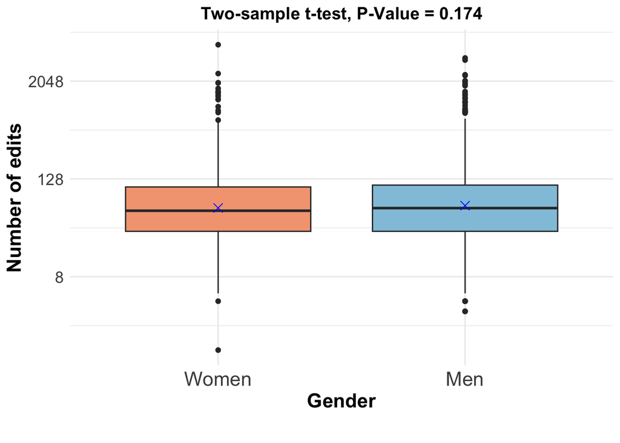

```r
 matched_data$total_edits_log2 <- log2(matched_data$total_edits)
t_test_result <- t.test(total_edits_log2 ~ sex, data = matched_data)


matched_edits <- ggplot(matched_data, aes(x = factor(sex, levels = c("female", "male"), labels = c("Women", "Men")), y = total_edits, fill = factor(sex, levels = c("female", "male")))) +
  geom_boxplot() +
    scale_fill_manual(values = c("female" = "#f4a582", "male" = "#92c5de")) +
  labs(title = paste("Two-sample t-test, P-Value = ", round(t_test_result$p.value, 3), add_stars(t_test_result$p.value), sep = ""),
       x = "Gender",
       y = "Number of edits", caption = "") +
  stat_summary(fun = mean, geom = "point", aes(group = sex),
               shape = 4, size = 3, color = "blue") +
   theme_minimal() +
  theme(
    panel.background = element_rect(fill = "white", colour = "white"),
    plot.background = element_rect(fill = "white", colour = NA),
    plot.title = element_text(hjust = 0.5, size = 14, face = "bold"),
    plot.caption = element_text(hjust = 0.5, size = 16),
    axis.title.x = element_text(size = 16, , face = "bold"),
    axis.title.y = element_text(size = 16, , face = "bold"),
    axis.text.x = element_text(size = 16),
    axis.text.y = element_text(size = 13)
  ) +
  guides(fill = FALSE)+
  scale_y_continuous(trans = 'log2')

ggsave(here("visualisations", "matched_boxplot5.pdf"), plot =  matched_edits, width = 5, height = 6, units = "in", dpi = 600)

matched_edits
```

### create tables for descriptive indicators

Now, we want to create tables, showing the variable of interest, the female and male means, the p-value and the effect size (Cohens’s d). First, we need to prepare the data for the next steps.

```r
#calculate statstics with log scales

descriptive_data_deu$text_length_career_log2 <- log2(descriptive_data_deu$text_length_career)
descriptive_data_deu$text_length_live_log2 <- log2(descriptive_data_deu$text_length_live)
descriptive_data_deu$text_length_log2 <- log2(descriptive_data_deu$text_length)
descriptive_data_deu$number_of_links_log2 <- log2(descriptive_data_deu$number_of_links)
descriptive_data_deu$total_edits_log2 <- log2(descriptive_data_deu$total_edits)

descriptive_data_matched$text_length_career_log2 <- log2(descriptive_data_matched$text_length_career)
descriptive_data_matched$text_length_live_log2 <- log2(descriptive_data_matched$text_length_live)
descriptive_data_matched$text_length_log2 <- log2(descriptive_data_matched$text_length)
descriptive_data_matched$number_of_links_log2 <- log2(descriptive_data_matched$number_of_links)
descriptive_data_matched$total_edits_log2 <- log2(descriptive_data_matched$total_edits)
```

apply functions

```r
#unmatched data
descriptives_deu <- calculate_statistics_log(descriptive_data_deu)
generate_table(descriptives_deu, "deu_descriptives")
```

| Variable | Female Mean | Male Mean | P_Value | Effect size |
| --- | --- | --- | --- | --- |
| Text length | 4755.596 | 4726.560 | 0.834 | -0.008 |
| Text length, career section | 596.034 | 553.204 | **0.041*** | -0.080 |
| Text length, life section | 708.413 | 792.639 | **0.000***** | 0.159 |
| Number of links | 40.844 | 43.651 | **0.009**** | 0.095 |
| Number of edits | 56.221 | 54.378 | 0.373 | -0.033 |

```r
#matched data
descriptives_matched <- calculate_statistics_log(descriptive_data_matched)
generate_table(descriptives_matched, "matched_descriptives")
```

| Variable | Female Mean | Male Mean | P_Value | Effect size |
| --- | --- | --- | --- | --- |
| Text length | 4755.596 | 5272.921 | **0.006**** | 0.126 |
| Text length, career section | 596.034 | 684.245 | **0.002**** | 0.151 |
| Text length, life section | 708.413 | 751.858 | 0.066 | 0.089 |
| Number of links | 40.844 | 44.432 | **0.008**** | 0.121 |
| Number of edits | 56.221 | 60.038 | 0.174 | 0.062 |

### Correlations

this code creates a correlation matrix for my data

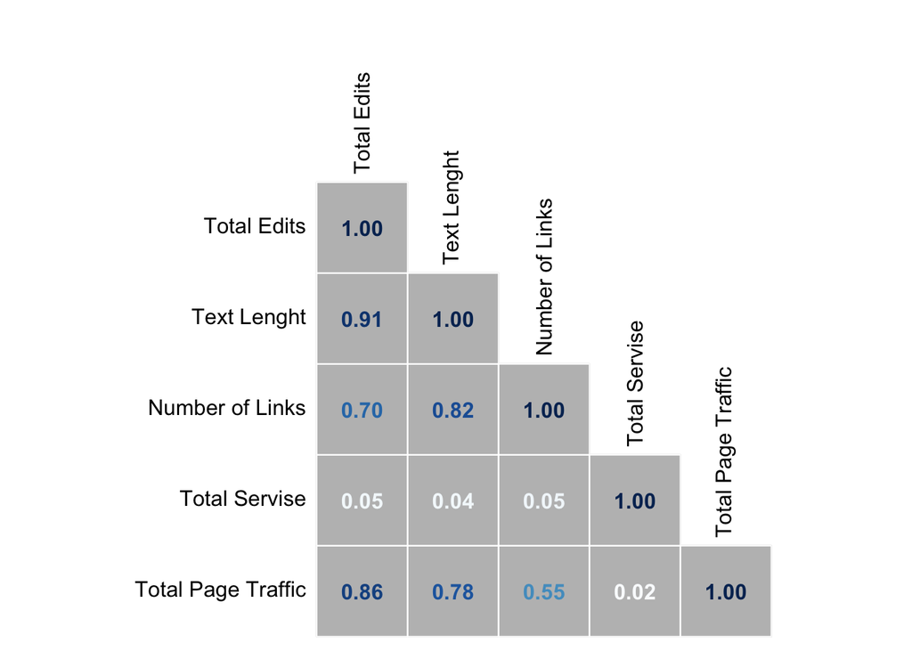

```r
# Select the relevant columns for correlation analysis from the 'deu' dataset
cor_data <- deu %>% select(total_edits, text_length, number_of_links,
                       total_service, total_traffic)


# Calculate the Pearson correlation matrix
COR <- cor(cor_data, method = "pearson")

# Custom labels for the columns and rows of the correlation matrix
custom_labels <- c("Total Edits", "Text Lenght", "Number of Links", "Total Servise", "Total Page Traffic")

# Assign custom labels to the column names and row names of the correlation matrix
colnames(COR) <- custom_labels
rownames(COR) <- custom_labels


# Plot the correlation matrix
plot_cor <- corrplot(COR, method = "number", type = 'lower', bg = "grey", tl.col = "black", cl.pos = 'n', addgrid.col= "white")
```

```r
# Define the file path for saving the plot as a PDF
pdf_file <- here("visualisations", "correlation.pdf")

# Save the plot as a PDF file
pdf(file = pdf_file)
corrplot(COR, method = "number", type = 'lower', bg = "grey", tl.col = "black", cl.pos = 'n', addgrid.col= "white")
dev.off()
```